# Example using RBPottery dataset from CRAN Archdata package: Exploratory analysis of archaeological ceramic compositions

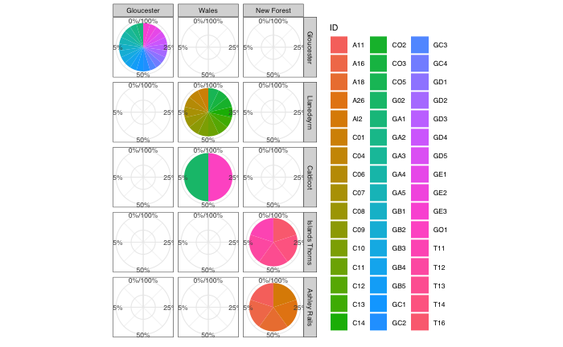

```r
arch_pie_plot(df_raw$ID,df_raw$Region, df_raw$Kiln)
```

###Boxplots with the distribution of the chemical elements

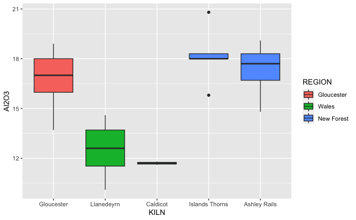

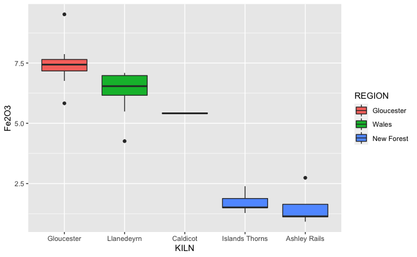

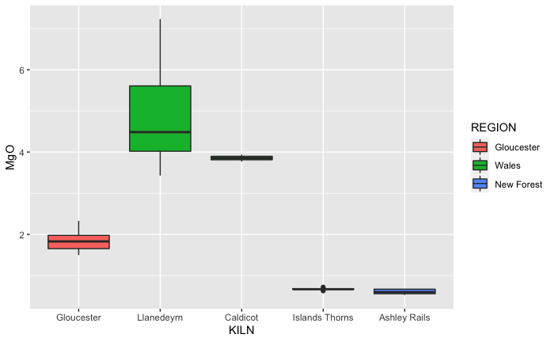

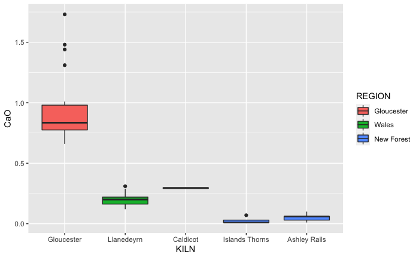

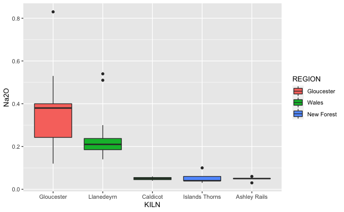

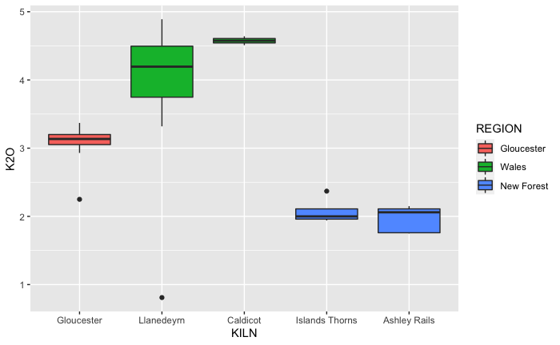

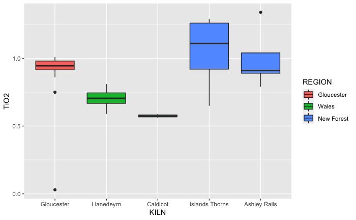

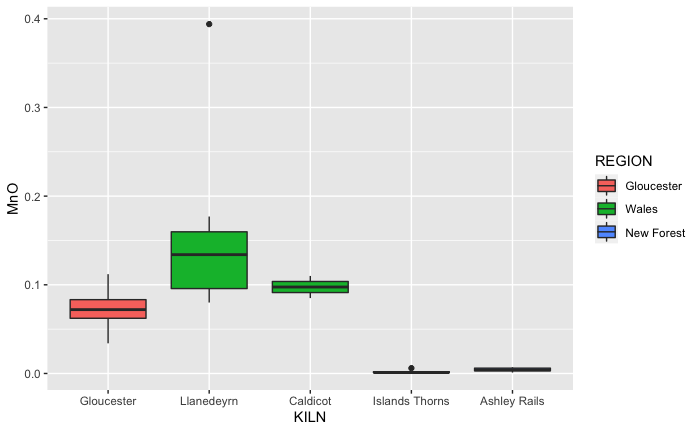

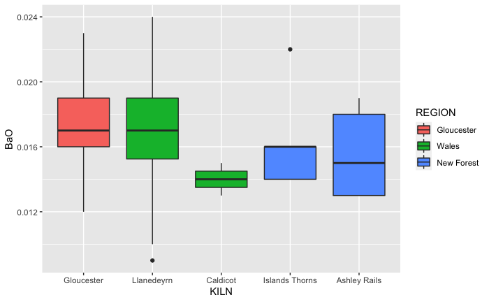

```r
  for (i in 1:ncol(df_chem)){
  .datt <- data.frame(REGION=df_raw$Region, i= df_chem[,i], KILN=df_raw$Kiln)
  plot(ggplot(.datt, aes(x= KILN, y = i, fill=REGION)) + geom_boxplot() + ylab(colnames(df_chem)[i]))
  }
```

###Create categories based on the calcium content or any other condition (optional)

```r
  df_raw$Calcium <- c() #Create the desired column

  "Low-Calcareous(CaO<6%)" ->   df_raw$Calcium[df_raw$CaO < 6]
  "Calcareous (6%<CaO<20%)" ->       df_raw$Calcium[df_raw$CaO> 6]
  "High Calcareous (CaO>%20)" -> df_raw$Calcium[df_raw$CaO > 20]

  df_raw$Calcium <- as.factor(df_raw$Calcium)  #bring back to factors
```

We might want to have a glance at which is the calcium content of the samples (two options)

```r
df_raw[,c("CaO", "Calcium")]
```

|  | CaO | Calcium |
| --- | --- | --- |
| GA1 | 0.79 | Low-Calcareous(CaO<6%) |
| GA2 | 0.84 | Low-Calcareous(CaO<6%) |
| GA3 | 0.77 | Low-Calcareous(CaO<6%) |
| GA4 | 1.01 | Low-Calcareous(CaO<6%) |
| GA5 | 0.76 | Low-Calcareous(CaO<6%) |
| GB1 | 0.92 | Low-Calcareous(CaO<6%) |
| GB2 | 0.87 | Low-Calcareous(CaO<6%) |
| GB3 | 1.73 | Low-Calcareous(CaO<6%) |
| GB4 | 1.00 | Low-Calcareous(CaO<6%) |
| GB5 | 0.71 | Low-Calcareous(CaO<6%) |

[output cut: 38 more lines]

```r
#select(df_raw,c(CaO,Calcareous))
```

##Applying statistics to the dataset

###Variation Matrix

```r
arch_varmat(df_chem)
```

```
%Values of vt/t.i (in Buxeda's notation).


  %Maximum determines variable to use as divisor in subsequent log-ratio transformation.


 % 0.5587909 0.9061 0.6586535 0.3133616 0.6429078 0.7281169 0.4332269 0.2787468 0.6358259

%Maximum value :  0.9061
%Variable :  2
            Al2O3     Fe2O3       MgO        CaO      Na2O       K2O      TiO2        MnO        BaO
Al2O3  0.00000000 0.5130187 0.7625391  2.0777534 0.8358279 0.1946776 0.2689208  2.8044199 0.05256085
Fe2O3  0.51301874 0.0000000 0.2800250  0.9492262 0.2934747 0.2792781 0.7934730  1.1101259 0.41261381
MgO    0.76253913 0.2800250 0.0000000  1.7316452 0.6674436 0.3110356 0.9927027  1.0598289 0.56590230
CaO    2.07775336 0.9492262 1.7316452  0.0000000 0.9480985 1.7801891 2.5579971  1.3386072 2.00792138
Na2O   0.83582792 0.2934747 0.6674436  0.9480985 0.0000000 0.6434720 1.1726813  1.2455265 0.72063586
K2O    0.19467764 0.2792781 0.3110356  1.7801891 0.6434720 0.0000000 0.4524119  1.9550258 0.14721809
TiO2   0.26892077 0.7934730 0.9927027  2.5579971 1.1726813 0.4524119 0.0000000  3.1479743 0.30013031
MnO    2.80441987 1.1101259 1.0598289  1.3386072 1.2455265 1.9550258 3.1479743  0.0000000 2.39287790
BaO    0.05256085 0.4126138 0.5659023  2.0079214 0.7206359 0.1472181 0.3001303  2.3928779 0.00000000
t.i    7.50971828 4.6312355 6.3711225 13.3914380 6.5271603 5.7633082 9.6862914 15.0543864 6.59986049
vt/t.i 0.55879091 0.9061000 0.6586535  0.3133616 0.6429078 0.7281169 0.4332269  0.2787468 0.63582591
r v,t  0.86883527 0.9746516 0.8527275  0.1260746 0.8427641 0.9193259 0.9127645  0.1732152 0.87521633
vt     4.19636229 0.0000000 0.0000000  0.0000000 0.0000000 0.0000000 0.0000000  0.0000000 0.00000000
```

###Graphically: Variation Matrix (MVC) plotCompositional evenness graph, MVC dendrogram and Coda-Dendrogram

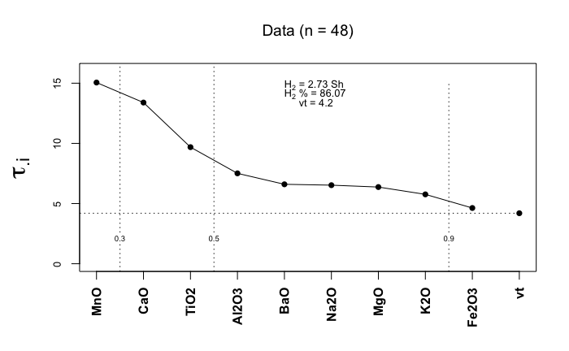

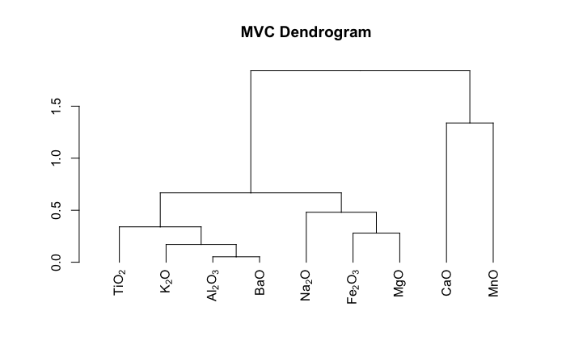

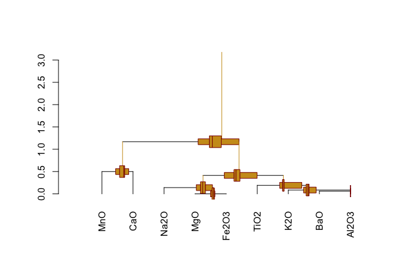

```r
arch_evenness(df_chem)
```

###Scatter plot Matrix

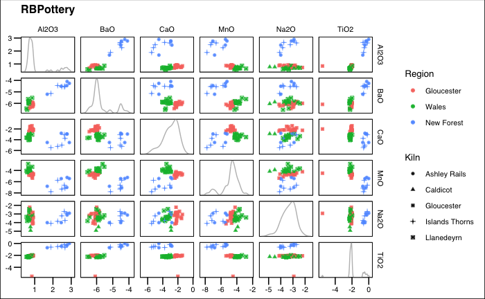

```r
  #select this with the variables to use
  vars <- c("MnO","CaO","Na2O", "TiO2","BaO", "Al2O3")

  #alr conversion
  alr(df_chem,ivar = 2)-> df_alr
  cbind(df_raw[,1:3],df_alr) -> df_alr

  arch_scatter_matrix(df_raw=df_alr, vars, color = "Region", shape = "Kiln", title= "RBPottery")
```

```r
  #a pdf file is saved in the working directory
  ##Ggcally package can offer similar kinds of visualizations
```

###Hierarchical Cluster Analysis (HCA)

Create the dendrograms based on the clr data. Required: define df_chem for numerical df_raw whole dataset (containing categorical data). If desired the emf and pdf can be directly saved to the local folder turning the argument of printDendro = TRUE, by default is false.

nplot: is the vector of plots to be displayed. Chose the index of categorical columns to be displayed.

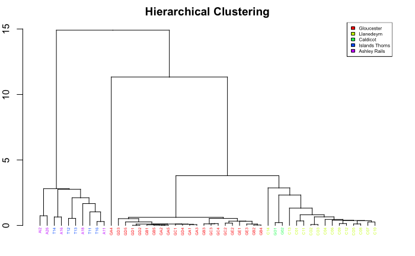

```
[1] "HCA using: Al2O3, Fe2O3, MgO, CaO, Na2O, K2O, TiO2, MnO, BaO"
[1] "Samples: 48"
```

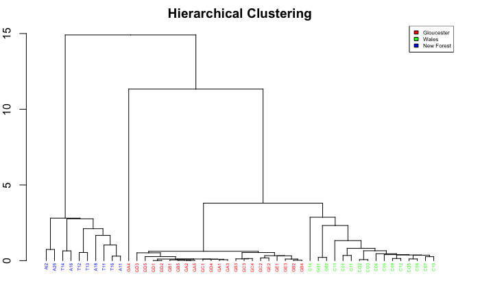

```r
arch_dendro(df_chem = df_chem, df_raw = df_raw, printDendro = FALSE, nplot=c(2,3))
```

###Principal Component Analysis (PCA)

For the alr transformation, the less variable element is generated in arch_evenness and saved as .lvar. Here “.lvar” is read automatically. nplot: is the vector of plots to be displayed. Chose the index of categorical columns to be displayed. printPCA = TRUE for generating pdf and emf files.

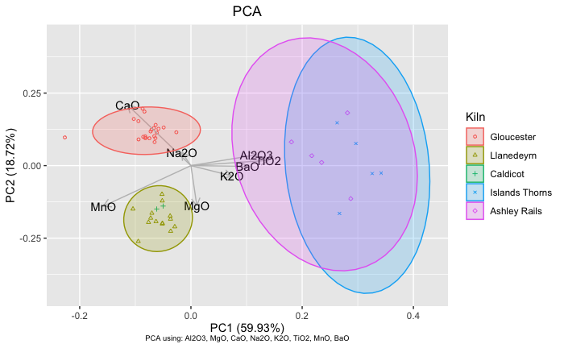

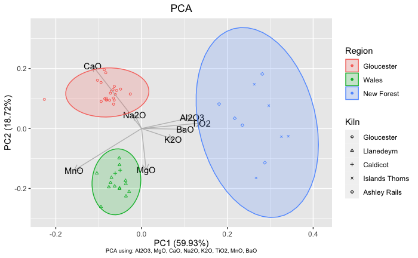

```r
arch_PCA(df_chem, df_raw =df_raw, printPCA= TRUE, labels = FALSE, nplot = c(2,3), shape_cat_number = 2)
```

###Heatmap (table with the concentrations)

```r
arch_heatmap(df_chem)
```

[interactive chart not shown]

###Ternary Diagram

Estimate SiO2 if not available in the dataset.

```r
SiO2 <- 0
total <- 98


if (!"SiO2" %in% colnames(df_chem) == TRUE)  {

      SiO2 <- 1

      df_chem$SiO2 <- c(rep(0, nrow(df_chem)))

  for (i in 1:nrow(df_chem)){

      df_chem$SiO2[i] <- total - sum(df_chem[i,])

      }

print("SiO2 column has been created by estimation")
cbind(df_raw[,c(1:3)], df_chem) -> df_raw

}
```

```
[1] "SiO2 column has been created by estimation"
```

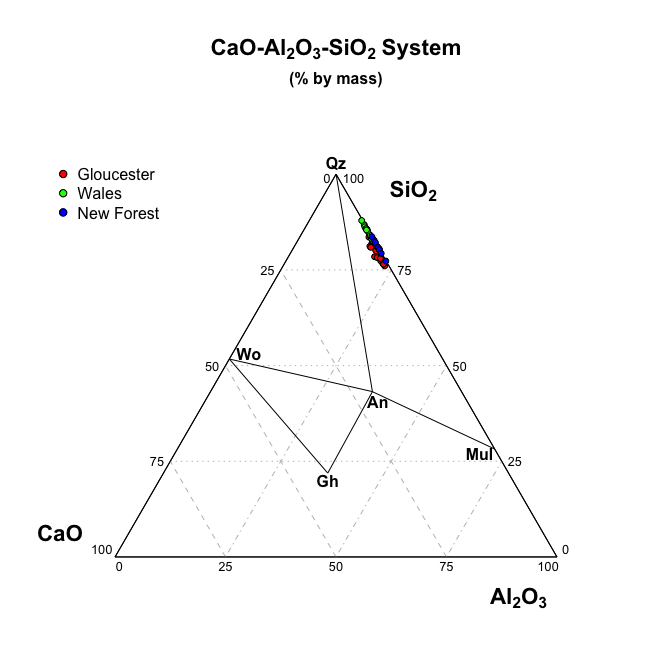

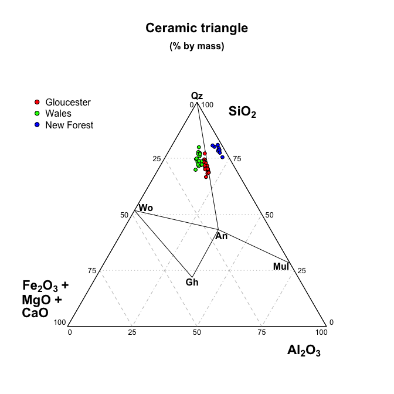

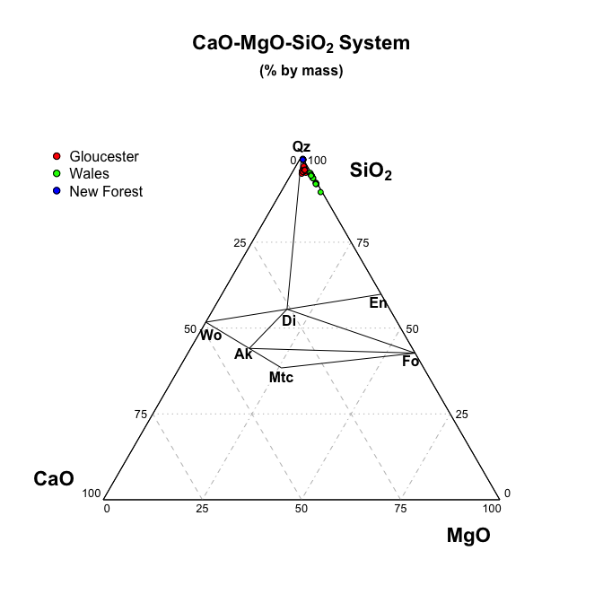

```r
arch_triangles(df_raw, grup =3) #grup = indicates the column from which the factors will be for the legend
```

```r
#Remove the column of estimated SiO2
if (SiO2 == 1){
  df_chem[,-c(ncol(df_chem))] -> df_chem
  df_raw[,-c(ncol(df_raw))] -> df_raw
  SiO2 <- 0
}
```

###Final Remarks

```
This is the first step of the ArchFlow workflow
```